# Praca domowa 2

Gerard Mańkowski

## Dane

Dane wykorzystane w Pracy domowej 2 są związane z kampaniami marketingu bezpośredniego portugalskiej instytucji bankowej. Kampanie marketingowe opierały się na rozmowach telefonicznych. Często wymagany był więcej niż jeden kontakt z tym samym klientem, aby uzyskać dostęp do tego, czy produkt (lokata bankowa) zostanie (lub nie) subskrybowany. Opis wszystkich kolumn znajduje się również w pliku `README.md`.

#### Dane klienta banku

| Zmienna | Opis |
| --- | --- |
| **age** | wiek |
| **job** : admin., unknown, unemployed, management, housemaid, entrepreneur, student, blue-collar, self-employed, retired, technician, services | administrator, nieznany, bezrobotny, kierownictwo, pokojówka, przedsiębiorca, student, pracownik fizyczny, samozatrudniony, emeryt, technik, usługi |
| **marital** : married, divorced, single; note: divorced means divorced or widowed) | żonaty/zamężna, rozwiedzion_, kawaler/panna; uwaga: rozwiedzion_ oznacza rozwiedzion_ lub owdowiał_ |
| **education** : unknown, secondary, primary, tertiary | nieznane, średnie, podstawowe, wyższe |
| **default** : yes, no | czy kredyt jest niespłacany : tak, nie |
| **balance** : average yearly balance, in euros | średnie roczne saldo w euro |
| **housing** : has housing loan? yes, no | czy posiada kredyt mieszkaniowy? tak, nie |
| **loan** : has personal loan? yes, no | ma pożyczkę osobistą? tak, nie |

#### Dane związane z ostatnim kontaktem w bieżącej kampanii

| Zmienna | Opis |
| --- | --- |
| **contact** : unknown, telephone, cellular | nieznany, telefon, komórkowy |
| **day** : last contact day of the month | dzień miesiąca ostatniego kontaktu |
| **month** : last contact month of year, jan, feb, mar, …, nov, dec | miesiąc ostatniego kontaktu w roku, styczeń, luty, marzec, …, listopad, grudzień |
| **duration** : last contact duration, in seconds | czas trwania ostatniego kontaktu w sekundach |

## Zadanie 1

Weźmy pod uwagę zawody (`job`) klientów banku. Który zawód zacząco wyróżnia się w posiadaniu kredytu mieszkaniowego lub pożyczki osobistej?

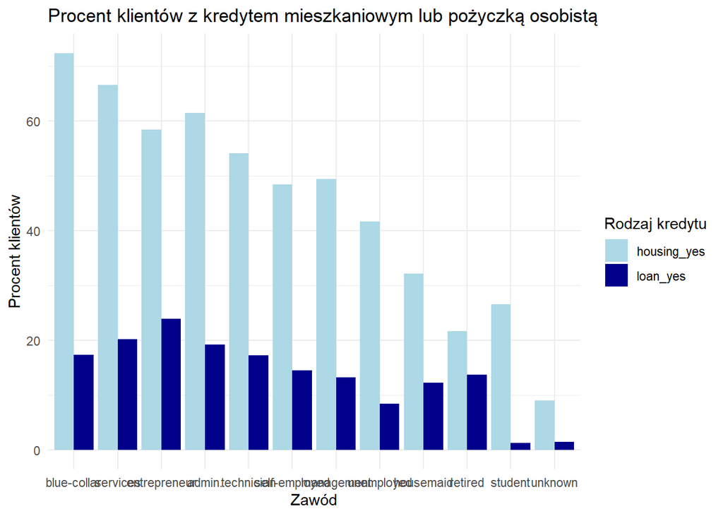

```r
job_comparison <- df %>%
  group_by(job) %>%
  summarise(
    housing_yes = mean(housing == "yes") * 100,
    loan_yes = mean(loan == "yes") * 100
  ) %>%
  pivot_longer(cols = c(housing_yes, loan_yes),
               names_to = "credit_type",
               values_to = "percentage")

ggplot(job_comparison, aes(x = reorder(job, desc(percentage)), y = percentage, fill = credit_type)) +
  geom_bar(stat = "identity", position = "dodge") +
  labs(title = "Procent klientów z kredytem mieszkaniowym lub pożyczką osobistą",
       x = "Zawód",
       y = "Procent klientów",
       fill = "Rodzaj kredytu") +
  scale_fill_manual(values = c("housing_yes" = "lightblue", "loan_yes" = "darkblue")) +
  theme_minimal()
```

**Komentarz:** Największy odsetek osób posiadających kredyt mieszkaniowy występuje w zawodzie blue-collar, a najmniejszy – wśród emerytów, z wyjątkiem osób o nieznanym zawodzie (unknown). Z kolei spośród osób posiadających pożyczkę osobistą najwięcej jest w zawodzie entrepreneur, a najmniej wśród studentów.

## Zadanie 2

Wybierając klientów, którzy mają nieznany sposób kontaktu (`contact`). Jak rozkłada się ich wiek w podziale na status związku?

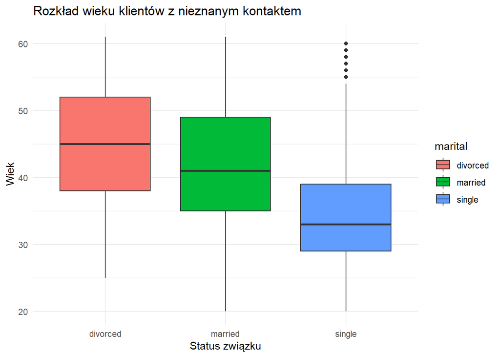

```r
unknown_contact <- df %>%
  filter(contact == "unknown")

ggplot(unknown_contact, aes(x = marital, y = age, fill = marital)) +
  geom_boxplot(alpha = 1) +
  labs(title = "Rozkład wieku klientów z nieznanym kontaktem",
       x = "Status związku",
       y = "Wiek") +
  theme_minimal()
```

## Zadanie 3

Jaka jest różnica pomiędzy średnim rocznym saldem w euro w zależności od wykształcenia i tego czy kredyt jest niespłacany?

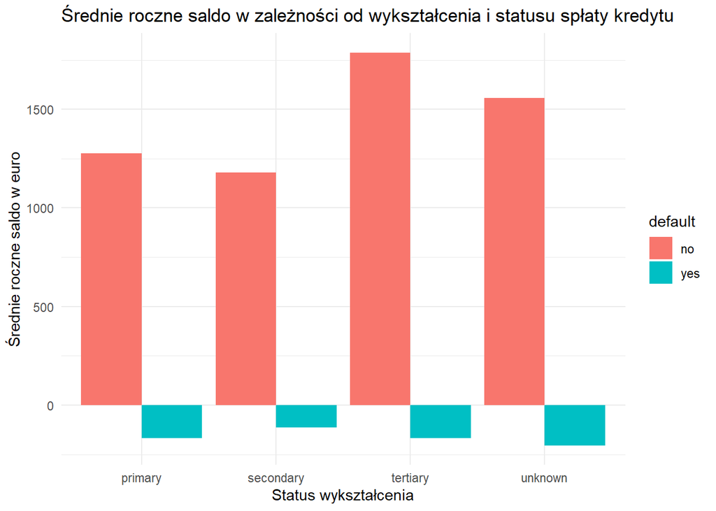

```r
balance_summary <- df %>%
  group_by(education, default) %>%
  summarise(average_balance = mean(balance, na.rm = TRUE)) %>% ungroup()

ggplot(balance_summary, aes(x = education, y = average_balance, fill = default)) +
  geom_col(position = "dodge") +
  labs(title = "Średnie roczne saldo w zależności od wykształcenia i statusu spłaty kredytu",
       x = "Status wykształcenia",
       y = "Średnie roczne saldo w euro") +
  theme_minimal()
```

## Zadanie 4

Czy dzień i miesiąc kontaktu z klientem ma wpływ na średni czas trwania rozmowy w stosunku do średniego czasu trwania rozmowy?

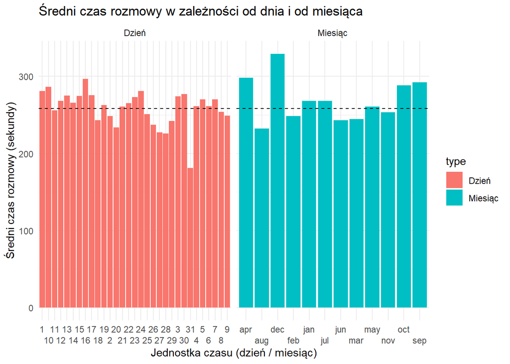

```r
total_avg_duration <- mean(df$duration, na.rm = TRUE)

daily_duration <- df %>%
  group_by(day) %>%
  summarise(avg_duration = mean(duration, na.rm = TRUE)) %>% mutate(type = "Dzień", day = as.character(day)) %>%
  rename(unit = day)

monthly_duration <- df %>%
  group_by(month) %>%
  summarise(avg_duration = mean(duration, na.rm = TRUE)) %>% mutate(type = "Miesiąc", month = as.character(month)) %>%
  rename(unit = month)

average_duration <- bind_rows(daily_duration, monthly_duration)

ggplot(average_duration, aes(x = unit, y = avg_duration, fill = type)) +
  geom_col() +
  geom_hline(yintercept = total_avg_duration, linetype = "dashed") +
  facet_wrap(~type, scales = "free_x") +
  labs(
    title = "Średni czas rozmowy w zależności od dnia i od miesiąca",
    x = "Jednostka czasu (dzień / miesiąc)",
    y = "Średni czas rozmowy (sekundy)"
  ) +
  scale_x_discrete(guide = guide_axis(n.dodge = 2)) +
  theme_minimal()
```

**Komentarz:** Największy średni czas trwania rozmowy w danym miesiącu wypadł w grudniu. Z kolei 31 - szego dnia miesiąca średni czas rozmów był znacząco krótszy w porównaniu z pozostałymi dniami.

## Zadanie 5

Czy jest zależnośc pomiędzy wiekiem klientów a ich średnim rocznym saldzie w euro w podziale na stopień wykształcenia?

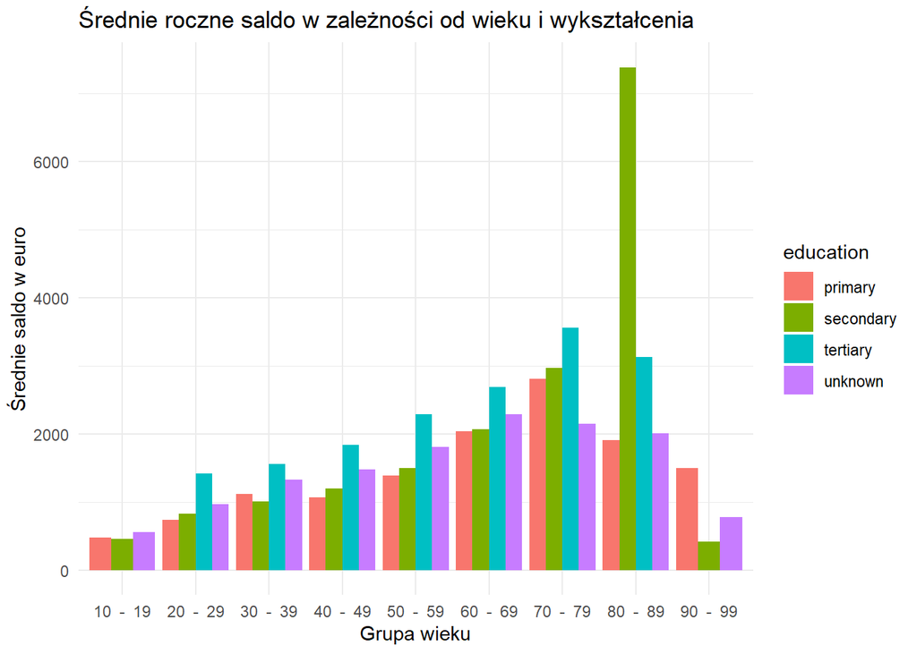

```r
age_summary <- df %>%
  mutate(age_group = cut(age, breaks = seq(0,100, by = 10), labels = paste(seq(0,90, by = 10), " - ", seq(9,99, by = 10)), right = FALSE)) %>%
  group_by(age_group, education) %>%
  summarise(average_balance = mean(balance, na.rm = TRUE))

ggplot(age_summary, aes(x = age_group, y = average_balance, fill = education)) +
  geom_bar(stat = "identity", position = "dodge") +
  labs(
    title = "Średnie roczne saldo w zależności od wieku i wykształcenia",
    x = "Grupa wieku",
    y = "Średnie saldo w euro") +
  theme_minimal()
```

**Komentarz:** W pierwszym przedziale wiekowym najwyższe średnie roczne saldo występuje wśród osób o nieznanym wykształceniu, natomiast w całym zakresie wieku - w przedziale 80 - 89 lat wśród osób o średnim wykształceniu. Poza przedziałami: 10 - 19, 80 - 89, 90 - 99, najwyższe średnie roczne saldo w każdym przedziale występuje u osób o wyższym wykształceniu.

## Zadanie 6

Rozważmy osoby, które są bezrobotne albo ich zawód jest nieznany. Czy procent osób, które są bezrobotne i nie spłacają kredytu jest większy od procenta osób o nieznanym zawodzie i niespłacanym kredycie? Jaki typ kredytu jest (przez te osoby) najczęściej niespłacany?

[figure not shown]

```r
default_summary <- df %>%
  filter(job %in% c("unemployed", "unknown")) %>%
  group_by(job) %>%
  summarise(default_yes = mean(default == "yes", na.rm = TRUE) * 100)

credit_type <- df %>%
  filter(job %in% c("unemployed", "unknown")) %>%
  group_by(job) %>%
  summarise(loan_yes = mean(loan == "yes", na.rm = TRUE) * 100,
            housing_yes = mean(housing == "yes", na.rm = TRUE) * 100) %>%
  pivot_longer(cols = c(housing_yes, loan_yes),
               names_to = "credit_type",
               values_to = "percentage") %>%
  ungroup()

p1 <- ggplot(default_summary, aes(x = job, y = default_yes, fill = job)) +
  geom_bar(stat = "identity", position = "dodge") +
  labs(title = "Procent niespłacających kredyt",
       x = "Grupa zawodowa",
       y = "Procent osób") +
  scale_fill_manual(values = c("unemployed" = "lightblue", "unknown" = "darkblue")) +
  theme_minimal()

p2 <- ggplot(credit_type, aes(x = job, y = percentage, fill = credit_type)) +
  geom_bar(stat = "identity", position = "dodge") +
  labs(title = "Typ kredytu niespłacanego",
       x = "Grupa zawodowa",
       y = "Procent osób",
       fill = "Typ kredytu") +
  scale_fill_manual(values = c("loan_yes" = "lightblue", "housing_yes" = "darkblue"),
                    labels = c("Pożyczka osobista",
                               "Kredyt mieszkaniowy")) +
  theme_minimal()

grid.arrange(p1, p2, ncol = 2)
```